# Pep2

sebastian de la fuente y benjamin moya

2025-06-30

# Pregunta 2

el gobierno regional de coquimbo desea identificar factores criticos que influyen en el acceso a la educacion superior de los habitantes de la region. En consecuencia, le ha solicitado contruir un modelo de regresion adecuado para predecir si las personas fueron o no aceptadas por una institucion de educacion superior, que use entre 2 y 5 predictores, asegurando que el modelo obtenido sea confiable. Determine si la calidad predictiva del modelo satisface los requerimientos del gobierno regional evaluandolo con validacion cruzada de 10 plieges. usando la semilla 5317

### Solucion

dado que se nos pide realizar una prediccion de una variable binaria, se debe utilizar un modelo de regresion logistica. Para ello, se debe seleccionar entre 2 y 5 variables predictoras que puedan influir en la variable de salida “Matriculado”. A continuacion, se realizara el analisis de los datos y la construccion del modelo.

Limpieza de datos y seleccion de predictores

```r
library(car)
```

```r
library(ggplot2)
library(caret)
library(dplyr)
library(ggpubr)
library(psych)
library(leaps)
library(pROC)
data=read.csv2("EI-2025-1-PE2-Datos.csv")
set.seed(5317)
data_coquimbo= data %>% filter(Region == "Coquimbo")
#eliminar la variable Xy la region no es de utilidad
data_coquimbo <- data_coquimbo %>% select(!all_of(c("X","Region")))
combinations <- regsubsets(Matriculado ~ ., data = data_coquimbo, nbest = 1, nvmax = 5, method = "exhaustive")
summary(combinations)
```

```
## Subset selection object
## Call: regsubsets.formula(Matriculado ~ ., data = data_coquimbo, nbest = 1,
##     nvmax = 5, method = "exhaustive")
## 7 Variables  (and intercept)
##             Forced in Forced out
## Sexo            FALSE      FALSE
## Tipo            FALSE      FALSE
## Egreso          FALSE      FALSE
## Nem             FALSE      FALSE
## Ranking         FALSE      FALSE
## Matematicas     FALSE      FALSE
## Lenguaje        FALSE      FALSE
## 1 subsets of each size up to 5
## Selection Algorithm: exhaustive
##          Sexo Tipo Egreso Nem Ranking Matematicas Lenguaje
## 1  ( 1 ) " "  " "  " "    " " " "     "*"         " "
## 2  ( 1 ) " "  " "  " "    " " "*"     "*"         " "
## 3  ( 1 ) " "  " "  " "    " " "*"     "*"         "*"
## 4  ( 1 ) " "  "*"  " "    " " "*"     "*"         "*"
## 5  ( 1 ) " "  "*"  "*"    " " "*"     "*"         "*"
```

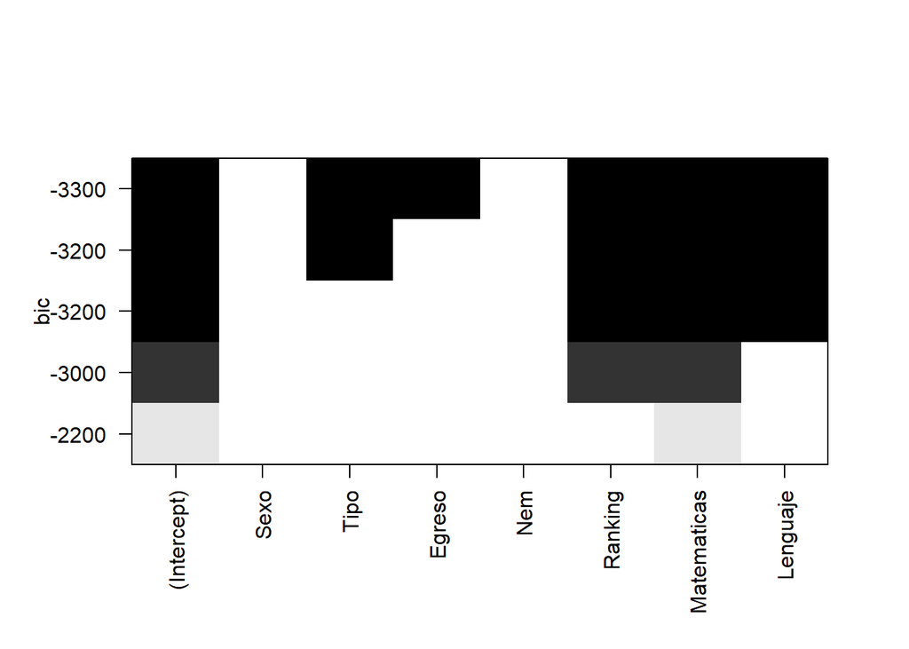

```r
plot(combinations)
```

Para la creacion del modelo se utilizaran como predictores las variables Ranking, Matematicas y Lenguaje. ya que como se observa en el grafico arrojado por la funcion regsubsets, son las variables con mas significancias a corde la variable de salida a evaluar.

para la creacion del modelo se usara la regresion hacia adelante donde se buscara obtener el modelo con mas significancia y que mas reduzca la RSS.

```r
modelonulo=glm(Matriculado ~ 1, data = data_coquimbo, family = binomial)
modelo1=update(modelonulo, as.formula(paste(". ~ . +", "Ranking")))
modelo2=update(modelo1, as.formula(paste(". ~ . +", "Matematicas")))
modelo3=update(modelo2, as.formula(paste(". ~ . +", "Lenguaje")))
anova(modelonulo, modelo1, modelo2, modelo3)
```

```
## Analysis of Deviance Table
##
## Model 1: Matriculado ~ 1
## Model 2: Matriculado ~ Ranking
## Model 3: Matriculado ~ Ranking + Matematicas
## Model 4: Matriculado ~ Ranking + Matematicas + Lenguaje
##   Resid. Df Resid. Dev Df Deviance  Pr(>Chi)
## 1      9249    12823.2
## 2      9248    10961.1  1   1862.1 < 2.2e-16 ***
## 3      9247     9662.4  1   1298.7 < 2.2e-16 ***
## 4      9246     9412.8  1    249.6 < 2.2e-16 ***
## ---
## Signif. codes:  0 '***' 0.001 '**' 0.01 '*' 0.05 '.' 0.1 ' ' 1
```

```r
AIC(modelonulo, modelo1, modelo2, modelo3)
```

```
##            df       AIC
## modelonulo  1 12825.223
## modelo1     2 10965.090
## modelo2     3  9668.404
## modelo3     4  9420.805
```

```r
BIC(modelonulo, modelo1, modelo2, modelo3)
```

```
##            df       BIC
## modelonulo  1 12832.355
## modelo1     2 10979.355
## modelo2     3  9689.801
## modelo3     4  9449.334
```

```r
summary(modelo3)
```

```
##
## Call:
## glm(formula = Matriculado ~ Ranking + Matematicas + Lenguaje,
##     family = binomial, data = data_coquimbo)
##
## Coefficients:
##               Estimate Std. Error z value Pr(>|z|)
## (Intercept) -6.4822193  0.1590782  -40.75   <2e-16 ***
## Ranking      0.0042668  0.0001785   23.91   <2e-16 ***
## Matematicas  0.0031341  0.0001963   15.97   <2e-16 ***
## Lenguaje     0.0029769  0.0001915   15.55   <2e-16 ***
## ---
## Signif. codes:  0 '***' 0.001 '**' 0.01 '*' 0.05 '.' 0.1 ' ' 1
##
## (Dispersion parameter for binomial family taken to be 1)
##
##     Null deviance: 12823.2  on 9249  degrees of freedom
## Residual deviance:  9412.8  on 9246  degrees of freedom
## AIC: 9420.8
##
## Number of Fisher Scoring iterations: 5
```

Como se observa en el analisis de modelos realizado, el modelo 3 es el que mejor ajusta los datos y el que mas minimiza la RSS, por lo que se seleccionara este modelo como el modelo final y a evaluar su confiabilidad y calidad predictiva.

Confiabilidad del modelo:

Recordar que se deben cumplir ciertas condiciones para verificar la confiabilidad del modelo las cuales son:

1- no debe existir multicolinealidad

2- independencia de los residuos

3- no influencia de los valores atipicos

```r
#multicolinealidad
vif(modelo3)
```

```
##     Ranking Matematicas    Lenguaje
##    1.036514    1.313566    1.293109
```

```r
#independencia de los residuos
durbinWatsonTest(modelo3)
```

```
##  lag Autocorrelation D-W Statistic p-value
##    1    0.0006738031      1.998406   0.928
##  Alternative hypothesis: rho != 0
```

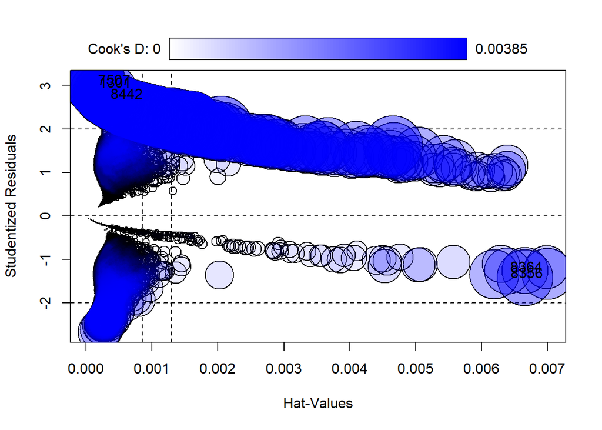

```
##        StudRes          Hat       CookD
## 1301  3.061129 0.0001328411 0.003540286
## 7507  3.125522 0.0001138918 0.003709152
## 8356 -1.324008 0.0069998854 0.002468165
## 8364 -1.174859 0.0069884060 0.001748913
## 8442  2.810247 0.0003050410 0.003851378
```

```r
#valores atipicos
influencePlot(modelo3)
```

Podemos comprobar gracias al resultado del test vif que no existe ninguna multicolinealidad entre las variables asignadas como predictores. Tambien se observa que no existe sobreinfluencia de los valores atipicos y finalmente gracias al test Durbin Watson se verifica que los residuos son independientes ya que el resultado de este no fue significativo. Por lo tanto al cumplir todas las condiciones anteriores podemos concluir que el modelo es confiable y se puede utilizar para predecir la variable de salida solicitada.

evaluacion de calidad predictiva del modelo utilizando validacion cruzada de 10 pliegues

```r
data_coquimbo$Matriculado <- factor(data_coquimbo$Matriculado, labels = c("No", "Si"))

control_entrenamiento <- trainControl(method = "cv",
                                      number = 10,
                                      # Es buena práctica guardar las predicciones para análisis posteriores
                                      savePredictions = TRUE,
                                      # Necesario para métricas como Sensibilidad, Especificidad, etc.
                                      classProbs = TRUE,
                                      summaryFunction = twoClassSummary)


modelo_final_cv <- train(Matriculado ~ Ranking + Matematicas + Lenguaje,
                         data = data_coquimbo,
                         method = "glm",
                         family = "binomial",
                         trControl = control_entrenamiento,
                         metric = "ROC")

print(modelo_final_cv)
```

```
## Generalized Linear Model
##
## 9250 samples
##    3 predictor
##    2 classes: 'No', 'Si'
##
## No pre-processing
## Resampling: Cross-Validated (10 fold)
## Summary of sample sizes: 8325, 8324, 8326, 8326, 8325, 8324, ...
## Resampling results:
##
##   ROC        Sens       Spec
##   0.8331769  0.7444373  0.7904883
```

```r
matriz=confusionMatrix(modelo_final_cv)
print(matriz)
```

```
## Cross-Validated (10 fold) Confusion Matrix
##
## (entries are percentual average cell counts across resamples)
##
##           Reference
## Prediction   No   Si
##         No 37.2 10.5
##         Si 12.8 39.5
##
##  Accuracy (average) : 0.7675
```

```r
# Curva ROC
roc_obj <- roc(data_coquimbo$Matriculado,
                as.numeric(predict(modelo_final_cv, type = "prob")[, "Si"]))
```

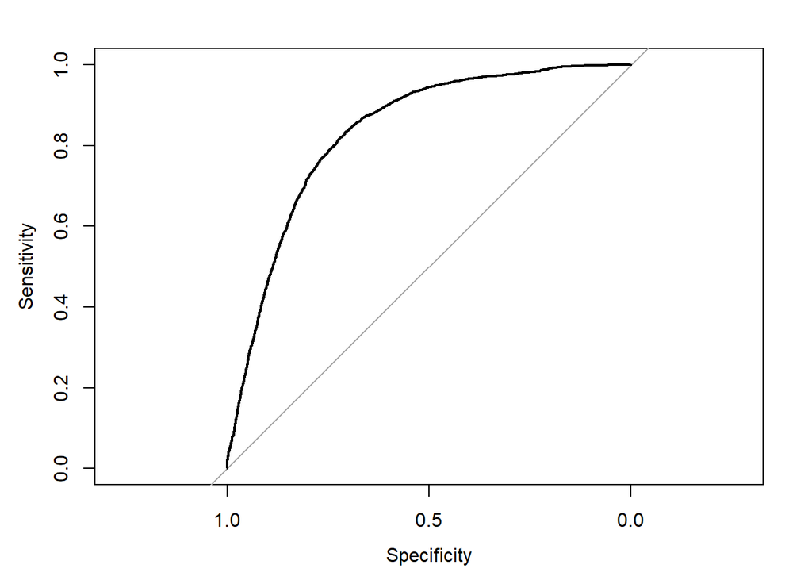

```r
plot(roc_obj)
```